# DATA621 Blog 1

William Aiken

2022-12-07

### Overview

Simple Linear Regression is one of the most important tools for an analyst to have in their tool box. For this blog post we are going to explore why you would use Simple Linear Regression. What assumptions are made when using it. How to check those assumptions and what to do if those assumptions aren’t met. Then we are going to use Simple Linear Regression on a real data set and examine the output.

$y = \alpha + \beta*x$

### Assumptions

- The errors(residuals) in the regression are approximately normally distributed
- The relationship is linear
- The observations are independent
- The data is normally distributed

### Example data set

We are going to explore the ‘diamonds’ data set that comes with the ‘ggplot2’ package. The diamonds data set contains the price and properties of ~54,000 diamonds. Let’s use the ‘glimpse’ function to look at a sample of the data

```r
library(ggplot2)
glimpse(diamonds)
```

```
## Rows: 53,940
## Columns: 10
## $ carat   <dbl> 0.23, 0.21, 0.23, 0.29, 0.31, 0.24, 0.24, 0.26, 0.22, 0.23, 0.…
## $ cut     <ord> Ideal, Premium, Good, Premium, Good, Very Good, Very Good, Ver…
## $ color   <ord> E, E, E, I, J, J, I, H, E, H, J, J, F, J, E, E, I, J, J, J, I,…
## $ clarity <ord> SI2, SI1, VS1, VS2, SI2, VVS2, VVS1, SI1, VS2, VS1, SI1, VS1, …
## $ depth   <dbl> 61.5, 59.8, 56.9, 62.4, 63.3, 62.8, 62.3, 61.9, 65.1, 59.4, 64…
## $ table   <dbl> 55, 61, 65, 58, 58, 57, 57, 55, 61, 61, 55, 56, 61, 54, 62, 58…
## $ price   <int> 326, 326, 327, 334, 335, 336, 336, 337, 337, 338, 339, 340, 34…
## $ x       <dbl> 3.95, 3.89, 4.05, 4.20, 4.34, 3.94, 3.95, 4.07, 3.87, 4.00, 4.…
## $ y       <dbl> 3.98, 3.84, 4.07, 4.23, 4.35, 3.96, 3.98, 4.11, 3.78, 4.05, 4.…
## $ z       <dbl> 2.43, 2.31, 2.31, 2.63, 2.75, 2.48, 2.47, 2.53, 2.49, 2.39, 2.…
```

Let’s use the ‘summary’ function to examine the central tendencies and distribution of the data set.

```r
summary(diamonds)
```

```
##      carat               cut        color        clarity          depth
##  Min.   :0.2000   Fair     : 1610   D: 6775   SI1    :13065   Min.   :43.00
##  1st Qu.:0.4000   Good     : 4906   E: 9797   VS2    :12258   1st Qu.:61.00
##  Median :0.7000   Very Good:12082   F: 9542   SI2    : 9194   Median :61.80
##  Mean   :0.7979   Premium  :13791   G:11292   VS1    : 8171   Mean   :61.75
##  3rd Qu.:1.0400   Ideal    :21551   H: 8304   VVS2   : 5066   3rd Qu.:62.50
##  Max.   :5.0100                     I: 5422   VVS1   : 3655   Max.   :79.00
##                                     J: 2808   (Other): 2531
##      table           price             x                y
##  Min.   :43.00   Min.   :  326   Min.   : 0.000   Min.   : 0.000
##  1st Qu.:56.00   1st Qu.:  950   1st Qu.: 4.710   1st Qu.: 4.720
##  Median :57.00   Median : 2401   Median : 5.700   Median : 5.710
##  Mean   :57.46   Mean   : 3933   Mean   : 5.731   Mean   : 5.735
##  3rd Qu.:59.00   3rd Qu.: 5324   3rd Qu.: 6.540   3rd Qu.: 6.540
##  Max.   :95.00   Max.   :18823   Max.   :10.740   Max.   :58.900
##
##        z
##  Min.   : 0.000
##  1st Qu.: 2.910
##  Median : 3.530
##  Mean   : 3.539
##  3rd Qu.: 4.040
##  Max.   :31.800
##
```

It’s helpful as a next step to look at histograms of all the variable in the data set. We can see that some of the variables are not normally distributed, most importantly ‘carat’ and ‘price’

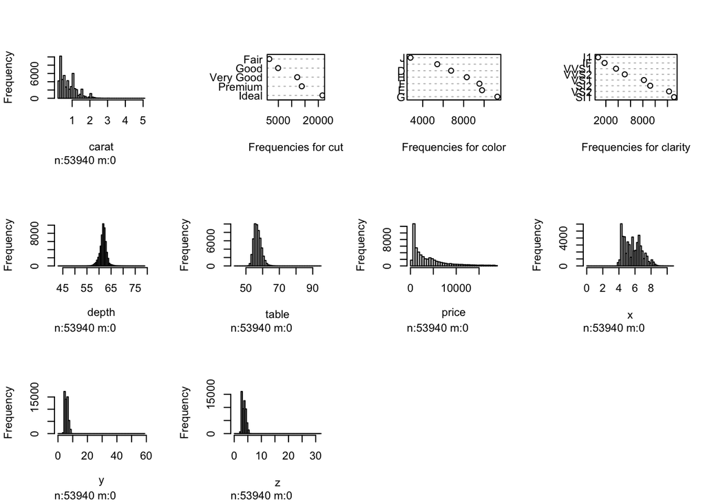

```r
Hmisc::hist.data.frame(diamonds)
```

### Analysis

Let’s build a simple linear model between price and carat. And then examine the output of the model.

```r
slm_1 <- lm(price~carat, diamonds)
summary(slm_1)
```

```
##
## Call:
## lm(formula = price ~ carat, data = diamonds)
##
## Residuals:
##      Min       1Q   Median       3Q      Max
## -18585.3   -804.8    -18.9    537.4  12731.7
##
## Coefficients:
##             Estimate Std. Error t value Pr(>|t|)
## (Intercept) -2256.36      13.06  -172.8   <2e-16 ***
## carat        7756.43      14.07   551.4   <2e-16 ***
## ---
## Signif. codes:  0 '***' 0.001 '**' 0.01 '*' 0.05 '.' 0.1 ' ' 1
##
## Residual standard error: 1549 on 53938 degrees of freedom
## Multiple R-squared:  0.8493, Adjusted R-squared:  0.8493
## F-statistic: 3.041e+05 on 1 and 53938 DF,  p-value: < 2.2e-16
```

Let’s use the ‘performance’ package to evaluate this model

We can see from the output of these plots that our data may be violating the assumptions of simple linear regression.

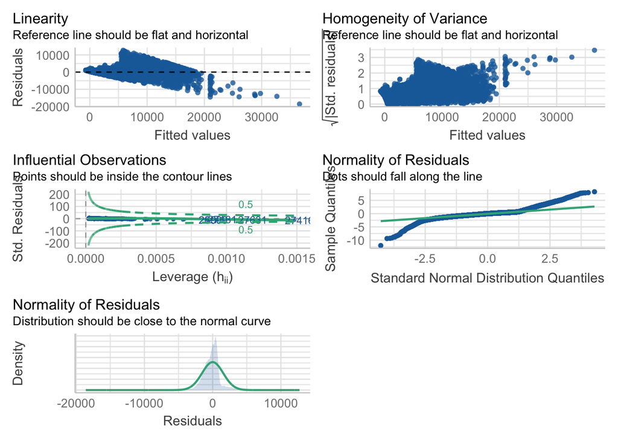

```r
performance::check_model(slm_1)
```

We are going to log transform both our predictor and dependent variable to see if this resolves some of our normality issues.

```r
diamonds <- diamonds %>% mutate(log_carat = log(carat), log_price = log(price))
```

Let’s rerun our linear model and examine the output. To be honest, I’m a little shocked how much this improved our model performance.

- We can see that our residuals are more normally distributed and the median is much closer to zero.
- Our coefficient for ‘log_carat’ has shrunk compared to the coefficient of ‘carat’ which is to be expected. The Std. Error has also shrunk dramatically improving the t value.
- The Residual standard error has shrunk and our Multiple R-squared has improved from 0.8493 to 0.933.

```r
slm_2 <- lm(log_price~log_carat, diamonds)
summary(slm_2)
```

```
##
## Call:
## lm(formula = log_price ~ log_carat, data = diamonds)
##
## Residuals:
##      Min       1Q   Median       3Q      Max
## -1.50833 -0.16951 -0.00591  0.16637  1.33793
##
## Coefficients:
##             Estimate Std. Error t value Pr(>|t|)
## (Intercept) 8.448661   0.001365  6190.9   <2e-16 ***
## log_carat   1.675817   0.001934   866.6   <2e-16 ***
## ---
## Signif. codes:  0 '***' 0.001 '**' 0.01 '*' 0.05 '.' 0.1 ' ' 1
##
## Residual standard error: 0.2627 on 53938 degrees of freedom
## Multiple R-squared:  0.933,  Adjusted R-squared:  0.933
## F-statistic: 7.51e+05 on 1 and 53938 DF,  p-value: < 2.2e-16
```

Lastly, let’s look at the model assumption graphs. We have transformed our data so that it better fits the assumptions of Simple Linear Regression.

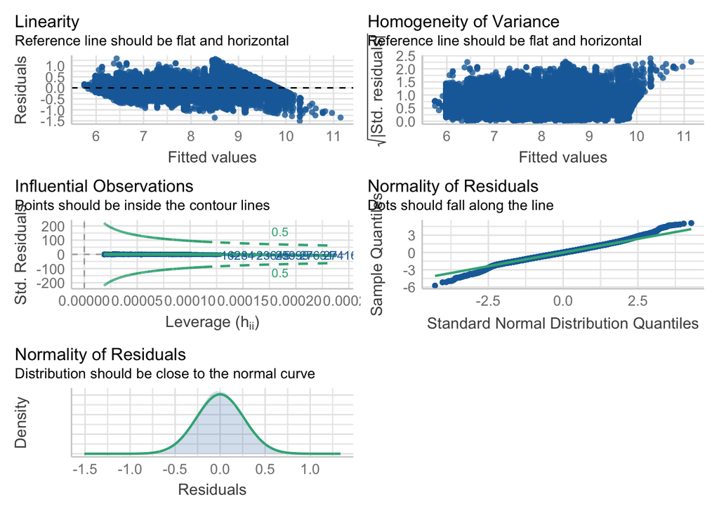

```r
performance::check_model(slm_2)
```

### Conclusion

We have shown that Simple Linear Regression can be a power tool for an analyst for predictive modeling. We have also shown how important it is to check that our model is conforming to the assumptions of Simple Linear Regression. In our case, the data needed to be log transformed and the resulting model has expected better performance (R-squared went from 0.8493 to 0.933). The one downside to log transforming our data is that we lose some of the interpretability. It’s harder to talk about the logs of diamond carats and prices.